# report_clean

#### 山东海科新源材料科技股份有限公司（301292.SZ）[2025Q3]

### 一、财报简评

海科新源在2025年三季度依旧保持高增长但仍未实现盈利。本季营收13.37亿人民币，同比大增80.43%，环比增长12.5%，延续了2024年末以来的复苏势头。主要得益于电解液溶剂需求旺盛、销量提升以及美元汇率上行。但公司仍录得归母净亏损0.85亿，同比亏损收窄17.4%；前三季度净利润累计亏损1.28亿，虽较去年同期减少四成，但公司仍处亏损状态。EPS为‑0.38元，略优于市场对持续亏损的悲观预期。

财报披露当天市场波动明显，股价先涨后跌，交易逻辑集中在“收入加速+毛利未显著改善”。投资者期待电解液溶剂需求带动的收入弹性，但对成本端压力和盈利修复节奏保持谨慎。公司前三季度经营现金流累计‑4.46亿元，第三季度单季现金流约‑1.98亿元，反映存货和应收周转仍占用大量资金，现金流压力是市场关注的另一核心。

### 二、公司信息

海科新源成立于2014年，2023年7月7日在深圳创业板上市。公司主营碳酸酯系列溶剂和丙二醇，为锂电池电解液核心溶剂供应商；同时生产汽柴油添加剂、食用香精香料等消费化学品。公司定位为“一站式电解液溶剂供应商”，依托“碳酸酯+丙二醇”双轮驱动模式拓展新能源材料与消费化学双赛道。2025年以来公司加码固态电解质、新型添加剂等新业务，与国内头部电解液企业展开合作，并在欧洲、美洲设立中转仓强化海外服务。

- **碳酸酯溶剂**：电解液溶剂业务是公司收入主力，2024年占比约69.5%，主要产品包含碳酸二甲酯(DMC)、碳酸乙烯酯(EC)等。公司与宁德时代、国轩高科等锂电池厂商合作，提供大宗溶剂和一站式配套服务。
- **丙二醇及副产品**：丙二醇业务收入约占2024年20.6%，毛利率仅4.09%，盈利能力较低。产品主要用于食品添加剂、化妆品等，出口占比较高。

### 三、关键数据：实际 vs 预期

[output not shown]

整体而言，公司收入大幅超预期，但毛利率尚未出现显著修复，盈利仍处亏损，市场情绪分化。

### 四、指引 vs 市场预期

- **下一季营收指引**：公司未发布具体数值指引，仅表示随着固态电解质中试装置投产、碳酸酯新线产能释放，预计四季度收入将继续保持同比高增；市场一致预期为10–12亿元区间。评价：**温和上行**。
- **利润/利润率指引**：管理层强调将通过原料采购优化和副产循环利用提升毛利率，力争全年毛利率较上年略有改善；但由于丙二醇价格仍低位运行，利润修复节奏可能偏慢，全年亏损收窄但难以扭亏。
- **全年更新**：公司维持“收入稳增长、盈利逐步修复”的经营目标，未调整全年业绩预期。市场情绪焦点集中在电解液扩产顺利度、丙二醇业务整合和海外市占率提升。订单增速放缓及毛利率能否修复是估值再定价的关键。

### 七、持续关注的老问题

- **盈利质量**：公司毛利率持续低位，净利率常年为负，非经常性收益（政府补助等）对利润影响显著。管理层正推进产品结构优化和成本控制，但短期盈利质量改善有限。
- **宏观行情与价格风险**：碳酸酯和丙二醇价格易受供需波动和国际油价影响。近年来行业供给释放导致溶剂价格下行，若需求不及预期，收入增速或承压。
- **去杠杆 / 负债压力**：为扩产公司举债较多，利息费用增加挤压利润。2024年末资产负债率约63%，需关注债务结构和融资成本变化。
- **产能爬坡 / 新项目良率**：新建碳酸酯及固态电解质产线需要时间爬坡，若良率不达预期或延迟投产，将影响收入释放并增加折旧摊销。

### 八、风险与机会

**机会（多头逻辑）**

1. **新能源需求回暖 → 出货量激增**：下游动力电池扩产及储能市场爆发，带动电解液需求提升，碳酸酯溶剂出货量持续上行，收入快速增长；若供需出现紧平衡，产品价格有望回升。
2. **固态电解质技术突破 → 盈利提升**：公司若在固态电解质及高端添加剂领域取得技术突破并成功商业化，将打开新的盈利空间，毛利率提升并打开估值重估空间。
3. **海外市场拓展 → 高毛利贡献**：通过设立海外仓和配套服务，海外订单占比持续提高，海外毛利率高于国内，业务结构改善有利于整体盈利能力。
4. **成本优化 → 经营杠杆释放**：集中采购、副产循环利用以及设备技改若成功落地，可有效降低单位成本，经营杠杆释放带来净利率上行。

**风险（空头逻辑）**

1. **行业供给过剩 → 价格下跌**：碳酸酯和丙二醇行业新增产能快速释放，若需求增长不及预期，产品价格或继续下跌，毛利率进一步压缩。
2. **新项目爬坡不顺 → 折旧拖累**：固态电解质和新溶剂项目若出现技术瓶颈或市场接受度低，将导致产能闲置，折旧和研发费用拖累业绩。
3. **海外扩张风险 → 管理挑战**：海外仓运营及客户开发涉及供应链管理和政策风险，若出现关税、汇率波动或运输问题，可能侵蚀海外业务利润。
4. **财务风险 → 利息负担加剧**：大规模扩产需要持续资本开支，若融资成本上升或现金流恶化，可能引发偿债压力和再融资风险。

形象地说：**“收入复苏快，但利润还在地上爬。”**

### 九、特别说明 / 投资启示

三季度财报体现出海科新源收入的加速度以及盈利的迟滞：电解液溶剂放量拉动收入大增，但原料价格下跌和丙二醇业务拖累致毛利率仍低。现金流承压和负债较高导致短期内投资者情绪偏谨慎。长期来看，公司布局固态电解质和功能添加剂，并积极拓展海外高毛利市场，这些因素为未来的盈利弹性提供了想象空间。投资者需区别短期盈利波动与长期业务价值，当前估值已计入部分悲观预期，若新项目顺利、市场需求回暖，公司利润有望逐步修复。人话结论：**基本面在修复，情绪面仍谨慎，业绩兑现是核心催化。**

### 十、可视化扩展

#### （2）主要经营指标数据

| 指标 | 营收 | 净利润 | 毛利率 | EPS | 经营现金流 | 备注 |
| --- | --- | --- | --- | --- | --- | --- |
| 2025Q3 | 13.37 | –0.85 | ≈3% | –0.38 | –1.98 | 收入同比+80% |
| 2025Q2 | 11.89 | –0.32 | — | — | 0.05 | 按半年报推算 |
| 2025Q1 | 11.27 | –0.11 | — | –0.05 | –2.53 | 新项目启动成本高 |
| 2024Q4 | 10.63 | –0.53 | — | — | 1.41 | 供需改善，现金流转正 |
| 2024Q3 | 7.41 | –1.03 | — | — | 2.11 | 丙二醇价格低拖累利润 |
| 2024Q2 | 9.52 | –0.49 | — | — | –0.36 | 电解液溶剂需求较弱 |
| 2024Q1 | 8.59 | –0.61 | — | –0.28 | –1.59 | 产品价格下跌 |

#### （3）主营业务或产品数据

| 业务/产品 | 收入占比 | 毛利率 | YoY | 库存 | 备注 |
| --- | --- | --- | --- | --- | --- |
| **碳酸酯溶剂** | 69.51% | 2.75% | +41.21% | 较高 | 锂电池电解液核心，贡献大 |
| **丙二醇** | 20.63% | 4.09% | –0.9% | 较低 | 价格下跌，盈利薄 |
| **其他消费化学品** | 9.86% | — | — | 一般 | 香精香料、燃料添加剂等 |
| **国内业务** | 81.66% | –0.46% | — | — | 竞争激烈，毛利低 |
| **海外业务** | 18.34% | 22.61% | — | — | 毛利高，是利润的主要来源 |

#### （4）趋势可视化（图表清单）

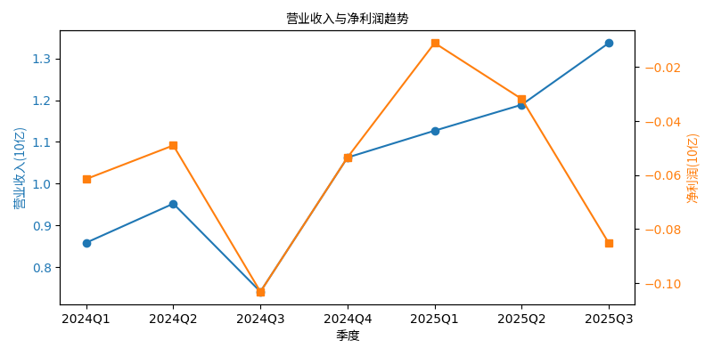

   营收与净利润趋势

2. **净利率变化**

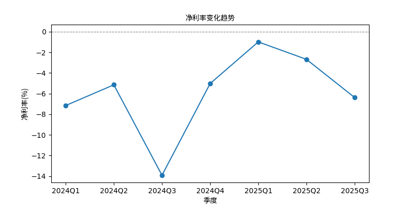

   净利率变化

3. **经营现金流趋势**

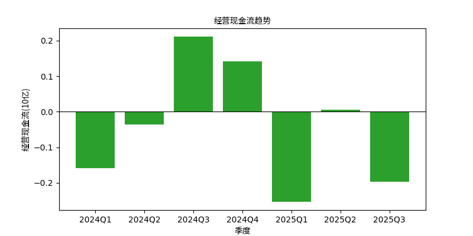

   经营现金流趋势

4. **产品结构与收入占比**

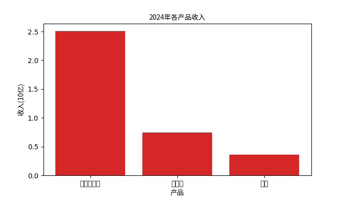

   2024年产品收入结构

5. **国内与海外收入比较**

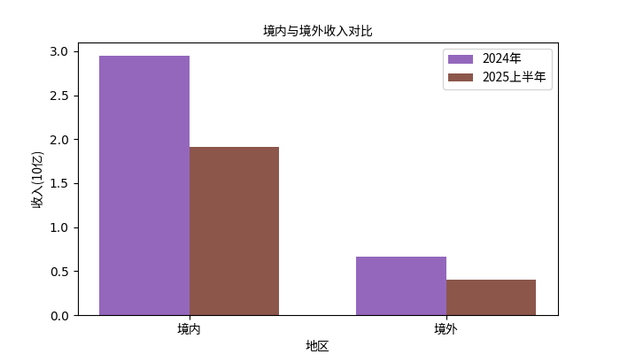

   国内与海外收入比较

6. **毛利率对比（碳酸酯 vs 丙二醇）**

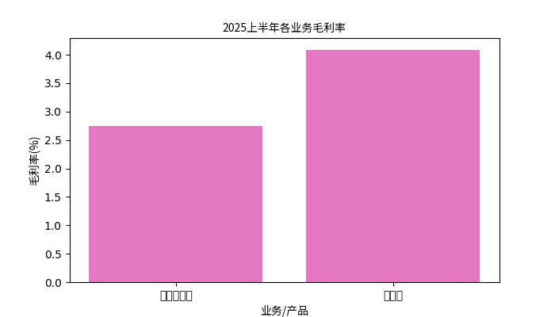

   毛利率对比

#### （6）数据来源与时间戳说明

全部数据来自公司公开披露的2024年度报告、2025半年度报告和2025三季报等文件。由于公司上市时间较短，历史数据有限；毛利率和CapEx等部分指标未披露，故未列出。汇率及市场预期为行业公开信息估算，非公司官方指引。